# Normality Test

[Sushank Pokhrel (Homepage)](https://sushank.com.np)

Assessing whether a dataset follows a normal distribution is a crucial step in statistical analysis.

### 1. Loading Required Libraries

You need to install the libraries (or packages) before they’re available in R. For that use the function `install.packages()`.

```r
library(readxl) # for reading the excel file.
```

```r
library(ggplot2) # for visualizing data
library(dplyr) # cleaning and filtering data
```

### 2. Importing the Dataset

```r
dummy_data <- readxl::read_excel(
  "D:/Drive/r_training/Datasets/dummy_data.xlsx",
  sheet = "Sheet1"
)
```

- `read_excel()` reads an Excel file from the specified path `("D:/Drive/r_training/Datasets/dummy_data.xlsx")`.
- The `sheet = "Sheet1"` argument specifies the worksheet to load.

### 3. Exploring the Data Structure

```r
str(dummy_data)
```

```
## tibble [1,500 × 3] (S3: tbl_df/tbl/data.frame)
##  $ data1: num [1:1500] 84.4 50.1 72 81.1 38.5 ...
##  $ data2: num [1:1500] 62.3 84 81.9 94.1 75.5 ...
##  $ data3: num [1:1500] 33 46.7 26.7 56.4 38.8 ...
```

```r
head(dummy_data)
```

```
## # A tibble: 6 × 3
##   data1 data2 data3
##   <dbl> <dbl> <dbl>
## 1  84.4  62.3  33.0
## 2  50.1  84    46.7
## 3  72    81.9  26.7
## 4  81.1  94.1  56.4
## 5  38.5  75.5  38.8
## 6  81.8  99.7  22.3
```

#### 4. Visualizing the Data Distribution

##### Using Density Plots

Density plots are used to understand the distribution of numerical variables.

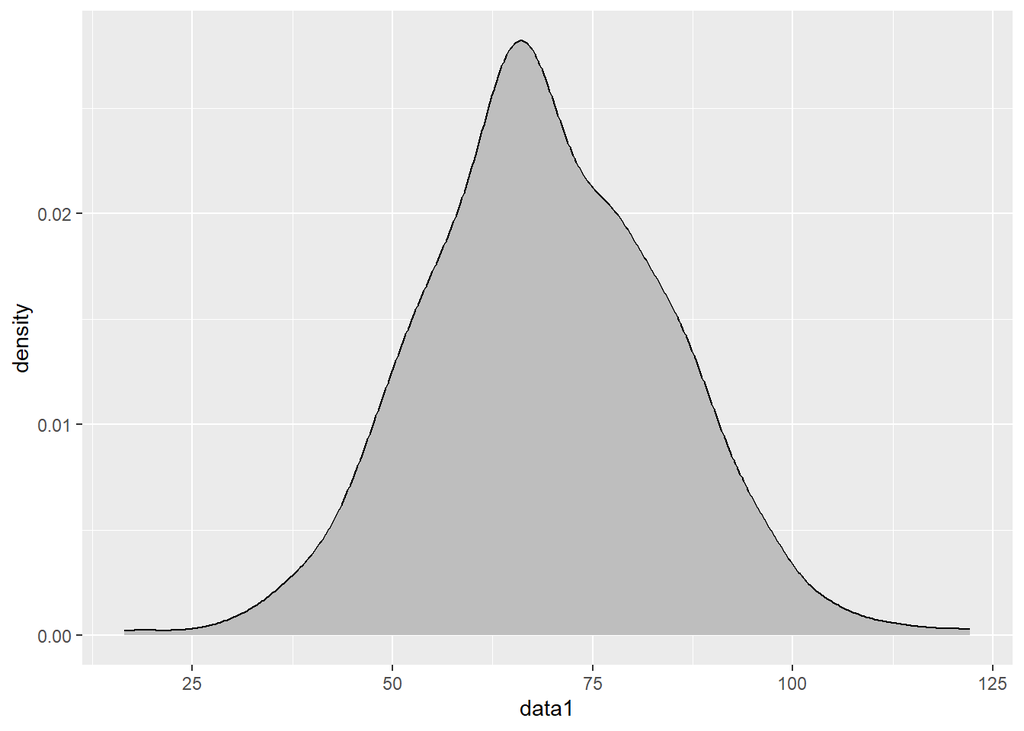

```r
ggplot() +
  geom_density(
    data = dummy_data,
    aes(x = data1),
    fill = "grey"
  )
```

- `ggplot()` Initializes the plotting object using the ggplot2 package.
- `geom_density()` Creates a density plot for the specified data.
- `aes(x = data1)`: Maps the data1 column to the x-axis.
- `fill = "grey"`: Fills the density plot with a grey color for better visualization.

The density plot here is somehow normally distributed as it shows bell shaped curve.

**Repeating for Other Columns**

You can create density plots for other variables in the dataset:

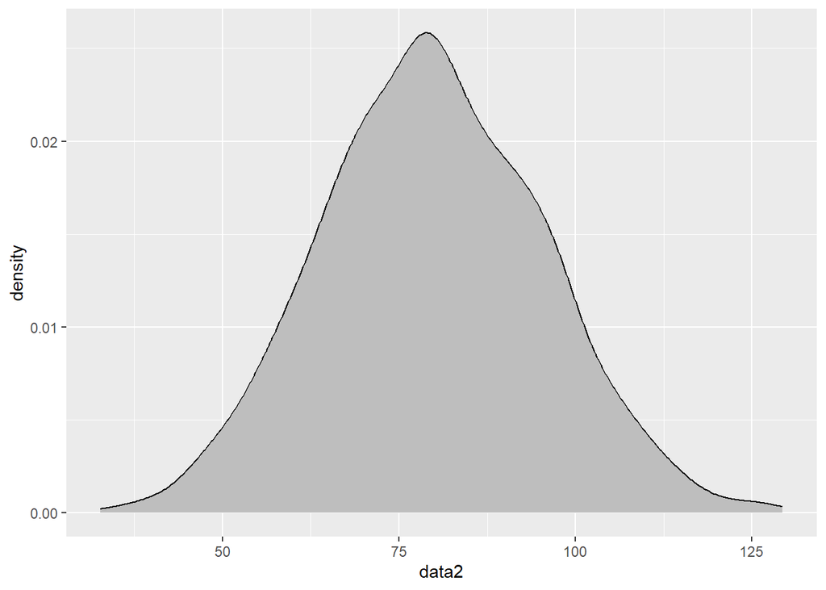

```r
# Density plot for data2
ggplot() +
  geom_density(
    data = dummy_data,
    aes(x = data2),
    fill = "grey"
  )
```

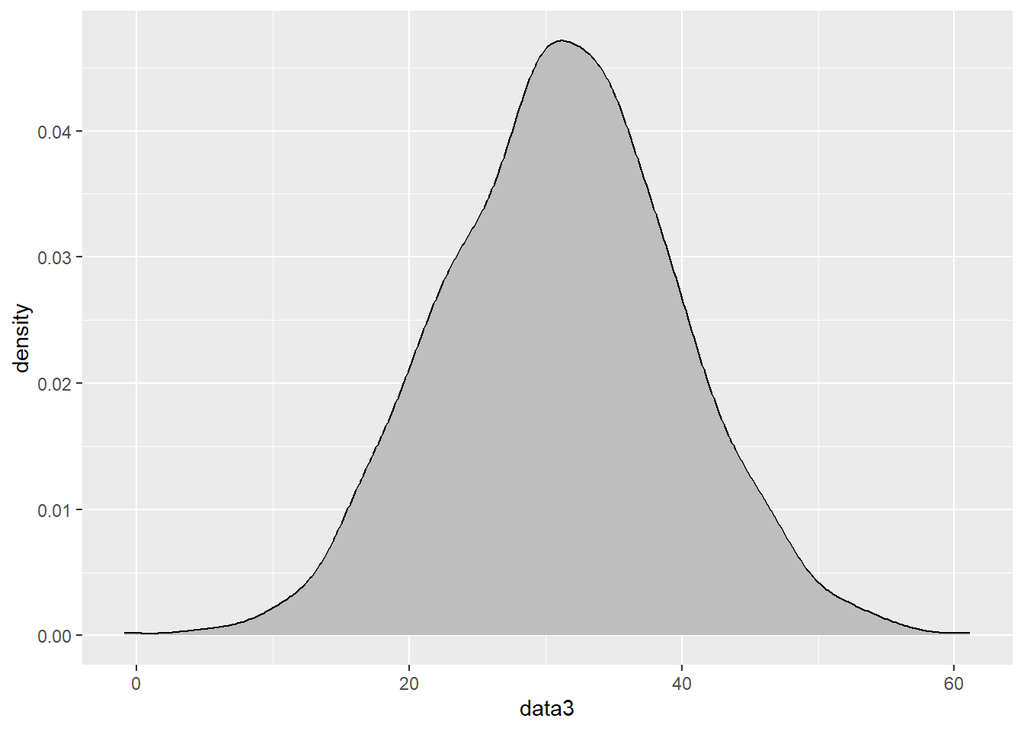

```r
# Density plot for data3
ggplot() +
  geom_density(
    data = dummy_data,
    aes(x = data3),
    fill = "grey"
  )
```

#### Assessing Normality with Q-Q Plots

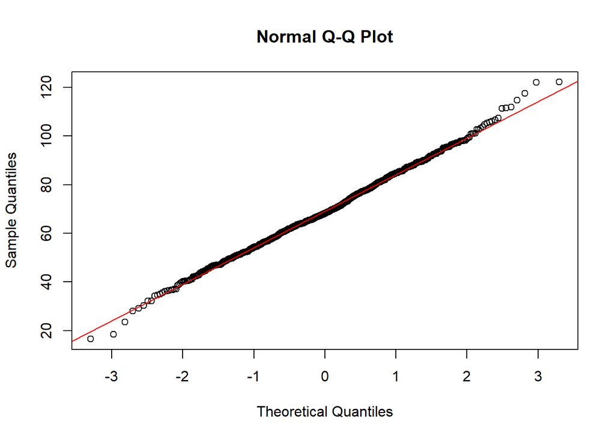

```r
qqnorm(dummy_data$data1)
qqline(dummy_data$data1, col = "red")
```

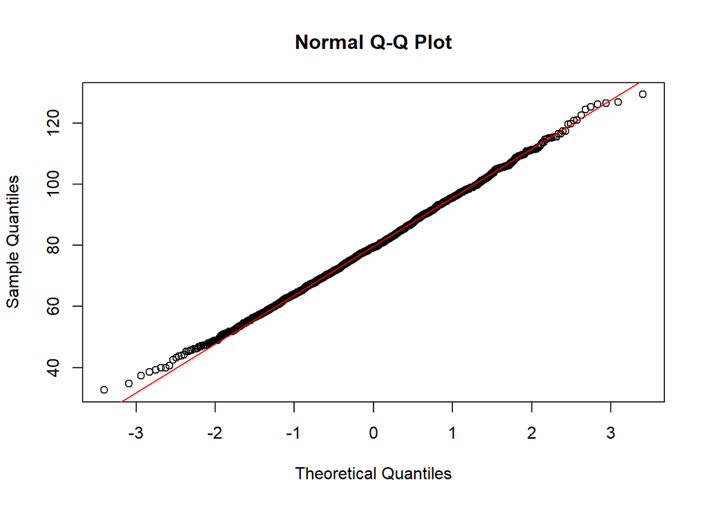

```r
qqnorm(dummy_data$data2)
qqline(dummy_data$data2, col = "red")
```

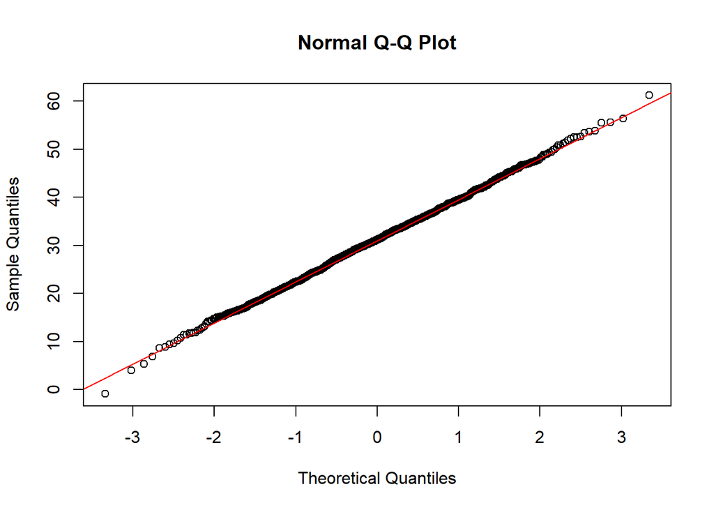

```r
qqnorm(dummy_data$data3)
qqline(dummy_data$data3, col = "red")
```

- `qqnorm()`: Creates the Q-Q plot for a dataset.
- `qqline()`: Adds a reference line to the Q-Q plot, indicating perfect normality. Deviations from this line suggest departures from normality.

Q-Q (Quantile-Quantile) plots are used to assess whether the data follows a normal distribution. A straight diagonal line suggests normality.

**Using `ggplot2` package for developing Q-Q plots.**

Q-Q plot for data1

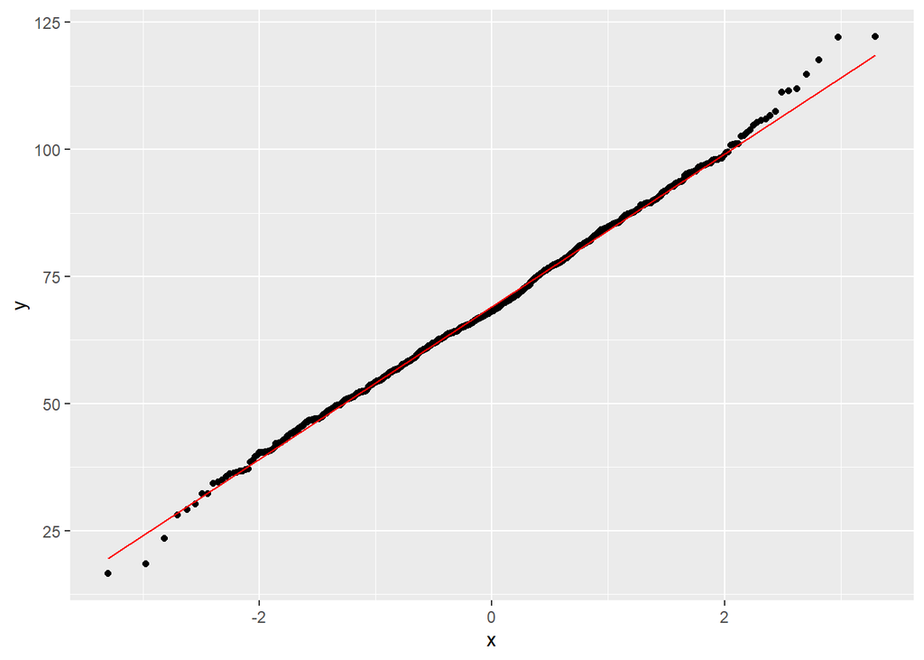

```r
ggplot(dummy_data, aes(sample = data1)) +
  stat_qq() +
  stat_qq_line(color = "red")
```

Q-Q plot for data2

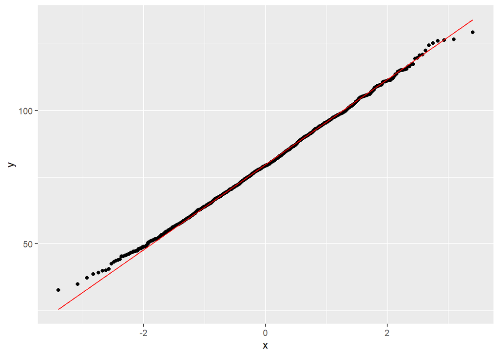

```r
ggplot(dummy_data, aes(sample = data2)) +
  stat_qq() +
  stat_qq_line(color = "red")
```

Q-Q plot for data3

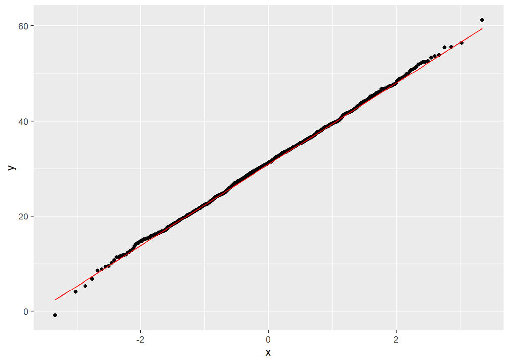

```r
ggplot(dummy_data, aes(sample = data3)) +
  stat_qq() +
  stat_qq_line(color = "red")
```

- `aes(sample = data1)`:Specifies the column to analyze (data1).
- `stat_qq()`: Creates the Q-Q plot by comparing the quantiles of the data to a theoretical normal distribution.
- `stat_qq_line()`: Adds a reference line to the Q-Q plot. If the points lie on or near the line, the data is approximately normally distributed.

### 5. Formal Tests for Normality

#### Shapiro-Wilk Test

The Shapiro-Wilk test is a widely used method for testing normality. It examines whether a dataset significantly deviates from a normal distribution.

**Test for data1**

```r
shapiro.test(dummy_data$data1)
```

```
##
##  Shapiro-Wilk normality test
##
## data:  dummy_data$data1
## W = 0.99782, p-value = 0.1992
```

**Test for data2**

```r
shapiro.test(dummy_data$data2)
```

```
##
##  Shapiro-Wilk normality test
##
## data:  dummy_data$data2
## W = 0.99889, p-value = 0.4874
```

**Test for data3**

```r
shapiro.test(dummy_data$data3)
```

```
##
##  Shapiro-Wilk normality test
##
## data:  dummy_data$data3
## W = 0.99938, p-value = 0.9742
```

- The null hypothesis (H₀): The data follows a normal distribution.
- If p < 0.05: Reject the null hypothesis (the data is not normal).
- If p ≥ 0.05: Fail to reject the null hypothesis (the data is approximately normal).
- The closer the test statistic is to 1, the closer the data is to normality.

##### Anderson-Darling Normality Test

The Anderson-Darling test is another formal method for testing normality, often more sensitive to deviations in the tails of the distribution.

You need the package `nortest` for this test.

```r
library(nortest) # you need to install the this package if not installed previously.

ad.test(dummy_data$data1)
```

```
##
##  Anderson-Darling normality test
##
## data:  dummy_data$data1
## A = 0.65992, p-value = 0.08472
```

```r
ad.test(dummy_data$data2)
```

```
##
##  Anderson-Darling normality test
##
## data:  dummy_data$data2
## A = 0.32739, p-value = 0.5185
```

```r
ad.test(dummy_data$data3)
```

```
##
##  Anderson-Darling normality test
##
## data:  dummy_data$data3
## A = 0.25286, p-value = 0.7347
```

- If p < 0.05: The data is not normal.
- If p ≥ 0.05: The data is approximately normal.

## Normality Tests on Long-Format Data

When data is structured in a “long format” (e.g., one column for variable names and another for corresponding values, normality tests must be conducted separately for each group (variable). This requires filtering data for each variable to test normality independently.

### 1. Loading the Excel File.

```r
# Load the long-format data
dummy_data_long <- readxl::read_excel(
  "D:/Drive/r_training/Datasets/dummy_data.xlsx",
  sheet = "Sheet2"
) |> na.omit() # Remove NA values
```

### 2. Inspect the data structure

```r
head(dummy_data_long)
```

```
## # A tibble: 6 × 2
##   variable values
##   <chr>     <dbl>
## 1 data3     -0.89
## 2 data3      4.04
## 3 data3      5.32
## 4 data3      6.84
## 5 data3      8.62
## 6 data3      8.8
```

```r
str(dummy_data_long)
```

```
## tibble [3,706 × 2] (S3: tbl_df/tbl/data.frame)
##  $ variable: chr [1:3706] "data3" "data3" "data3" "data3" ...
##  $ values  : num [1:3706] -0.89 4.04 5.32 6.84 8.62 ...
##  - attr(*, "na.action")= 'omit' Named int [1:17] 111 307 443 780 998 1368 1579 1798 2018 2049 ...
##   ..- attr(*, "names")= chr [1:17] "111" "307" "443" "780" ...
```

### 3. Confirm there are no missing values

```r
sum(is.na(dummy_data_long))
```

```
## [1] 0
```

There are none.

### 4. Filtering Data & Performing normality test

#### Using `dplyr::filter()` to Extract Data

```r
# Extract data for 'data1'
data1 <- dummy_data_long |>
  dplyr::filter(variable == "data1")
```

**Verify the unique group name**

```r
unique(data1$variable)  # Output: "data1"
```

```
## [1] "data1"
```

**Performing Shapiro-Wilk Test for Normality**

```r
shapiro.test(data1$values)
```

```
##
##  Shapiro-Wilk normality test
##
## data:  data1$values
## W = 0.99782, p-value = 0.2022
```

#### Using Base R to Filter Data

```r
# Extract data for 'data2'
data2 <- dummy_data_long[dummy_data_long$variable == "data2", ]
```

**Perform the Shapiro-Wilk test**

```r
shapiro.test(data2$values)
```

```
##
##  Shapiro-Wilk normality test
##
## data:  data2$values
## W = 0.9989, p-value = 0.4975
```

### 5. Testing Without Extracting Subsets

Normality tests can be performed directly on specific subsets without creating intermediate variables. It can be quite tricky.

Data in must be in vector format for normality testing.

#### Directly using base function to extract the dataset and checking its class.

```r
# Check the class of the subsetted column
dummy_data_long[dummy_data_long$variable == "data3", "values"] |> class()
```

```
## [1] "tbl_df"     "tbl"        "data.frame"
```

It is a table data frame, or simply data frame. Therefore, we can’t perform the test in it, as it needs to be a numeric vector.

#### Converting it into a numeric vector

```r
# Convert to a vector using `[[1]]`
dummy_data_long[dummy_data_long$variable == "data3", "values"][[1]] |> class()
```

```
## [1] "numeric"
```

It is a numeric vector.

#### Alternatively, we can use the function `pull()` from `dplyr` package for converting it into a numeric vector

```r
# Convert to a vector using `pull()`
dummy_data_long[dummy_data_long$variable == "data3", "values"] |>
  dplyr::pull(values) |> class()
```

```
## [1] "numeric"
```

It is also a numeric vector.

#### Perform the Shapiro-Wilk test directly in the numeric vector.

```r
shapiro.test(
  dummy_data_long[dummy_data_long$variable == "data3", "values"][[1]]
)
```

```
##
##  Shapiro-Wilk normality test
##
## data:  dummy_data_long[dummy_data_long$variable == "data3", "values"][[1]]
## W = 0.99938, p-value = 0.9741
```

#### OR using `pull()` function from the dplyr package.

```r
shapiro.test(
  dummy_data_long[dummy_data_long$variable == "data3", "values"] |>
    dplyr::pull(values)
)
```

```
##
##  Shapiro-Wilk normality test
##
## data:  dplyr::pull(dummy_data_long[dummy_data_long$variable == "data3", "values"], values)
## W = 0.99938, p-value = 0.9741
```

**Alternatively,**

```r
  dummy_data_long[dummy_data_long$variable == "data3", "values"] |>
  dplyr::pull(values) |>
  shapiro.test()
```

```
##
##  Shapiro-Wilk normality test
##
## data:  dplyr::pull(dummy_data_long[dummy_data_long$variable == "data3", "values"], values)
## W = 0.99938, p-value = 0.9741
```

## Normality testing with the other dataset.

### 1. Loading and Exploring the Data

The dataset contains electricity utility rates across various states in the U.S. The goal is to compare the commercial rates (comm_rate) among selected states.

```r
# Load the dataset
electricity <- readxl::read_excel(
  "D:/Drive/r_training/Datasets/electricity_utility_rates.xlsx",
  sheet = "sheet1"
)

# Inspect the structure of the dataset
str(electricity)
```

```
## tibble [52,177 × 9] (S3: tbl_df/tbl/data.frame)
##  $ zip         : num [1:52177] 85321 36560 36513 36280 35473 ...
##  $ eiaid       : num [1:52177] 176 195 195 195 195 195 195 195 195 195 ...
##  $ utility_name: chr [1:52177] "Ajo Improvement Co" "Alabama Power Co" "Alabama Power Co" "Alabama Power Co" ...
##  $ state       : chr [1:52177] "AZ" "AL" "AL" "AL" ...
##  $ service_type: chr [1:52177] "Bundled" "Bundled" "Bundled" "Bundled" ...
##  $ ownership   : chr [1:52177] "Investor Owned" "Investor Owned" "Investor Owned" "Investor Owned" ...
##  $ comm_rate   : num [1:52177] 0.0879 0.1219 0.1219 0.1219 0.1219 ...
##  $ ind_rate    : num [1:52177] 0 0.0637 0.0637 0.0637 0.0637 ...
##  $ res_rate    : num [1:52177] 0.0939 0.1351 0.1351 0.1351 0.1351 ...
```

```r
# Check the unique states available in the data
unique(electricity$state)
```

```
##  [1] "AZ" "AL" "AK" "MI" "IA" "VA" "WV" "AR" "TN" "NJ" "MD" "ME" "NC" "SC" "NY"
## [16] "LA" "WY" "OH" "PA" "IL" "CT" "WI" "DE" "NM" "TX" "KS" "MO" "OK" "MA" "FL"
## [31] "GA" "VT" "HI" "ID" "OR" "IN" "KY" "MT" "ND" "SD" "MN" "MS" "RI" "NV" "CA"
## [46] "UT" "WA" "DC" "CO" "NH"
```

The dataset contains utility rates for 50 states. For simplicity, we select four states: “AZ”, “MI”, “IA”, and “VA”.

### 2. Filtering the Data

```r
# Filter data for selected states
elec_filt <- electricity |>
  dplyr::filter(
    state %in% c("AZ", "MI", "IA", "VA")
  )
```

### 3. Visualizing the Data

#### Density Plot

Density plot for all selected states

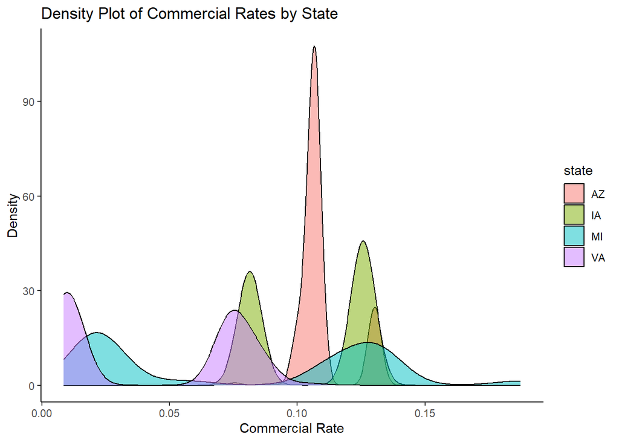

```r
ggplot(
  data = elec_filt,
  aes(x = comm_rate, fill = state)
) +
  geom_density(alpha = 0.5) +
  theme_classic() +
  labs(title = "Density Plot of Commercial Rates by State",
       x = "Commercial Rate",
       y = "Density")
```

#### Density Plots for Each State

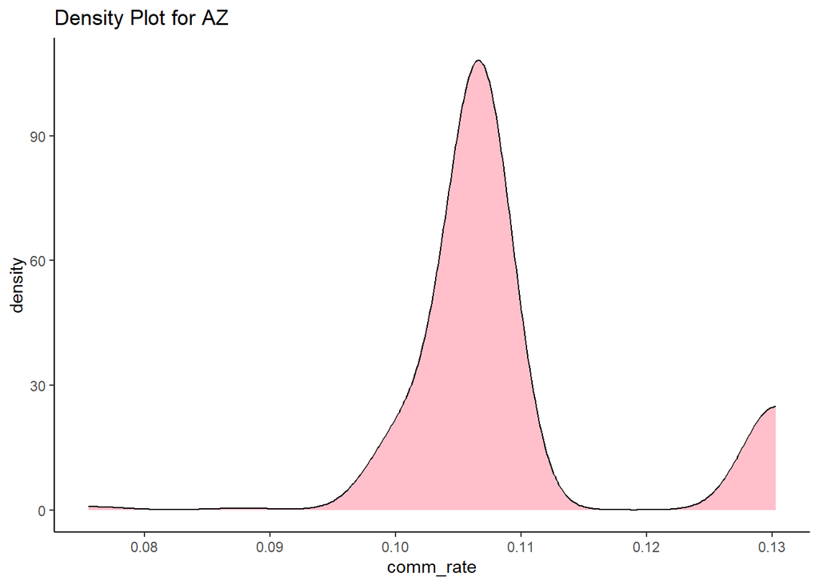

```r
ggplot(data = elec_filt[elec_filt$state == "AZ", ], aes(x = comm_rate)) +
  geom_density(fill = "pink") +
  theme_classic() +
  labs(title = "Density Plot for AZ")
```

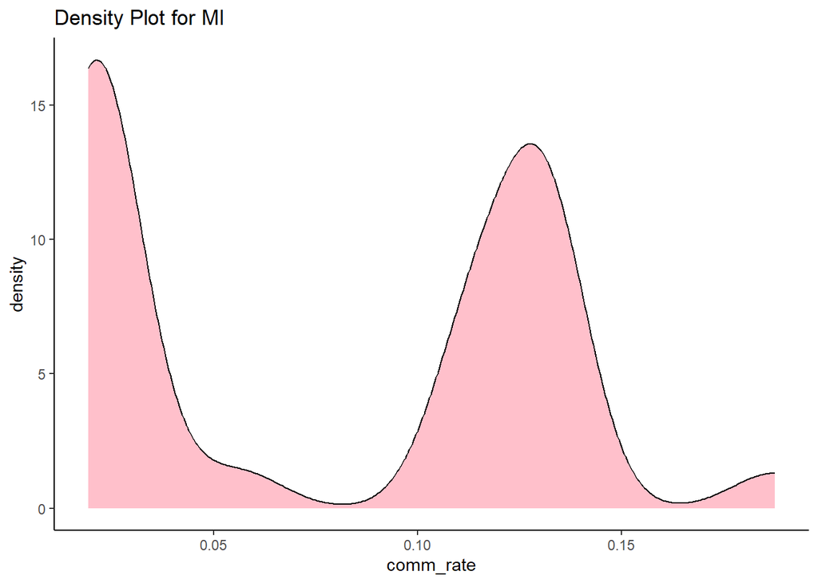

```r
ggplot(data = elec_filt[elec_filt$state == "MI", ], aes(x = comm_rate)) +
  geom_density(fill = "pink") +
  theme_classic() +
  labs(title = "Density Plot for MI")
```

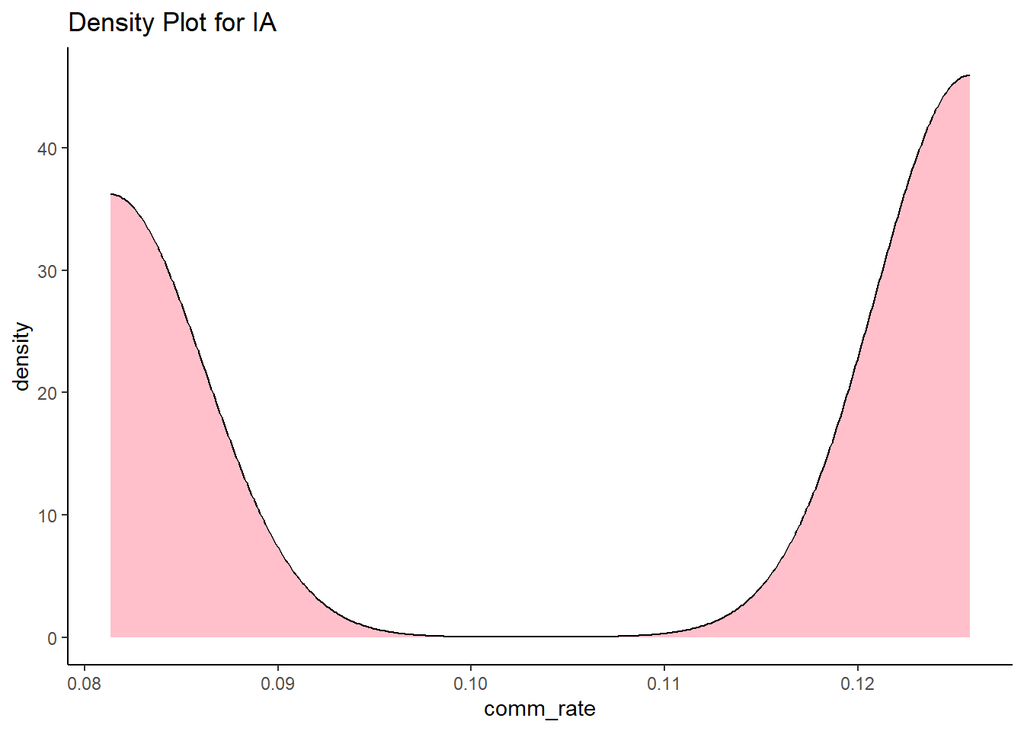

```r
ggplot(data = elec_filt[elec_filt$state == "IA", ], aes(x = comm_rate)) +
  geom_density(fill = "pink") +
  theme_classic() +
  labs(title = "Density Plot for IA")
```

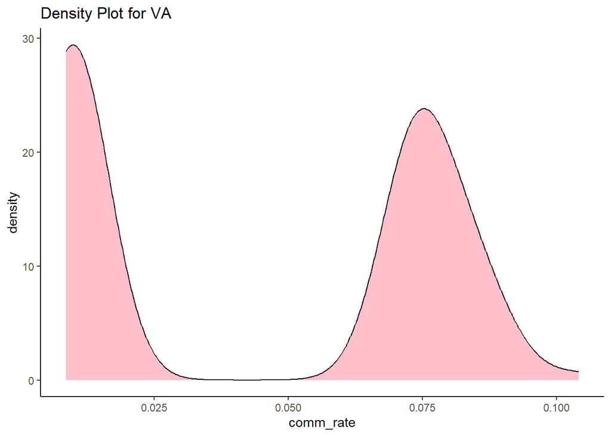

```r
ggplot(data = elec_filt[elec_filt$state == "VA", ], aes(x = comm_rate)) +
  geom_density(fill = "pink") +
  theme_classic() +
  labs(title = "Density Plot for VA")
```

### 4. Testing for Normality

#### Quantile-Quantile (QQ) Plot

**QQ plot for each state**

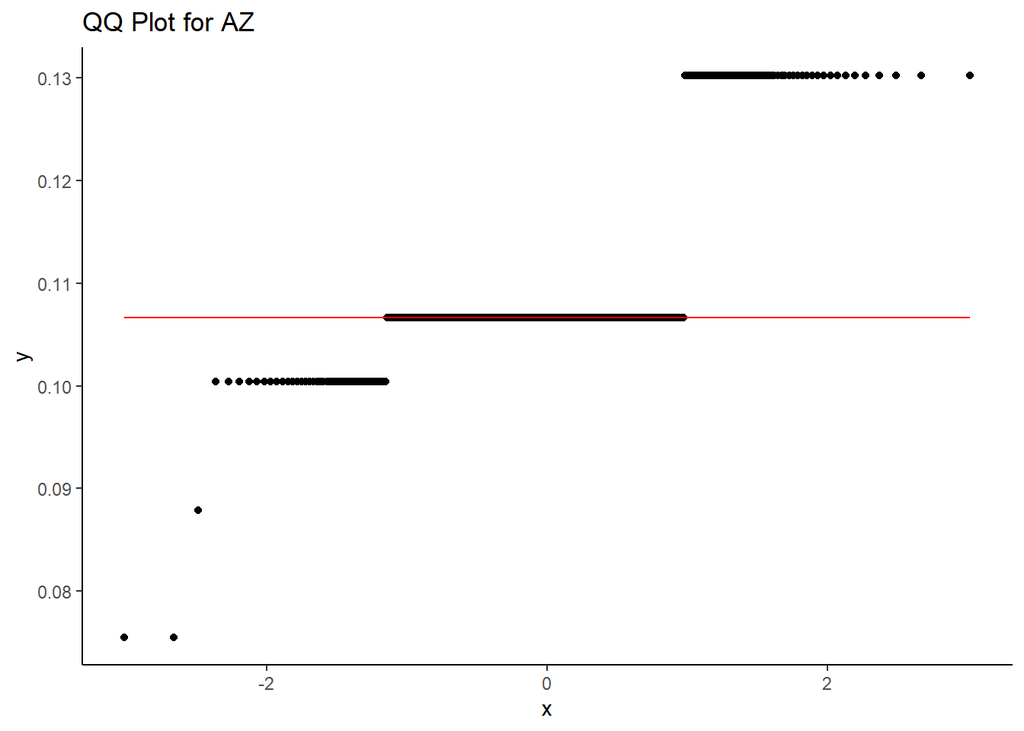

```r
ggplot(data = elec_filt[elec_filt$state == "AZ", ], aes(sample = comm_rate)) +
  stat_qq() +
  stat_qq_line(color = "red") +
  theme_classic() +
  labs(title = "QQ Plot for AZ")
```

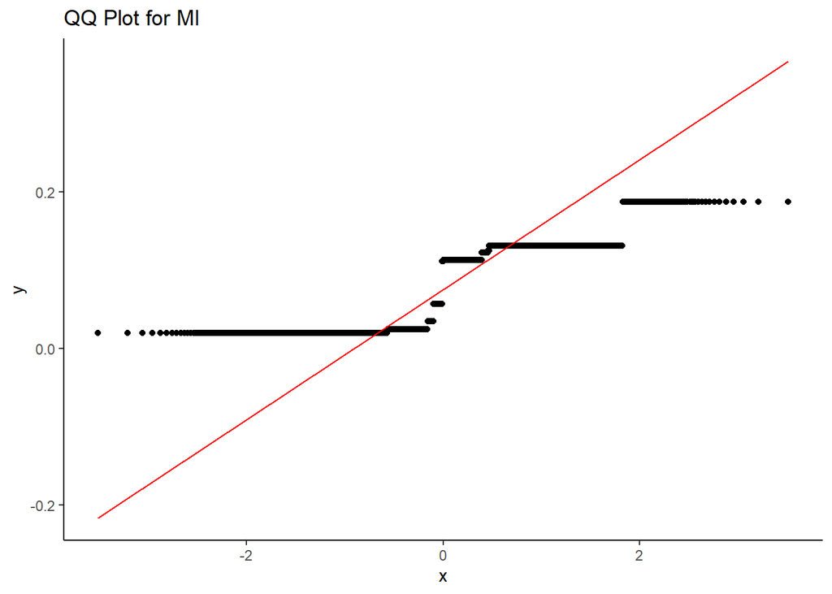

```r
ggplot(data = elec_filt[elec_filt$state == "MI", ], aes(sample = comm_rate)) +
  stat_qq() +
  stat_qq_line(color = "red") +
  theme_classic() +
  labs(title = "QQ Plot for MI")
```

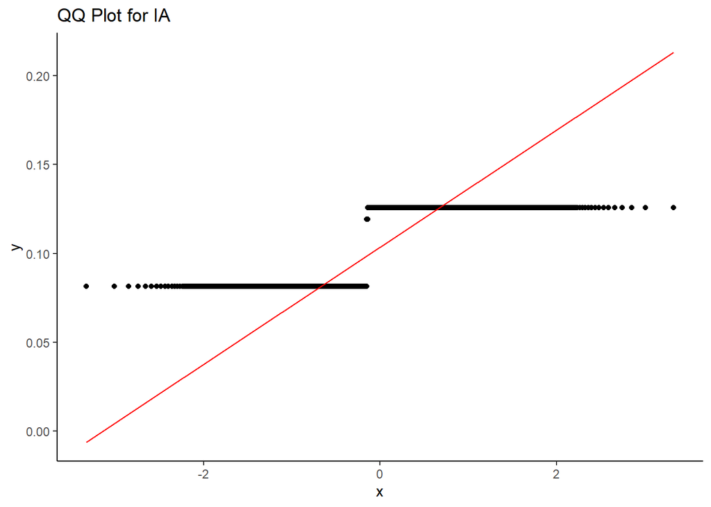

```r
ggplot(data = elec_filt[elec_filt$state == "IA", ], aes(sample = comm_rate)) +
  stat_qq() +
  stat_qq_line(color = "red") +
  theme_classic() +
  labs(title = "QQ Plot for IA")
```

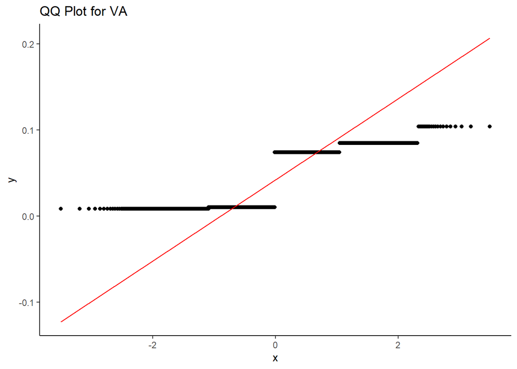

```r
ggplot(data = elec_filt[elec_filt$state == "VA", ], aes(sample = comm_rate)) +
  stat_qq() +
  stat_qq_line(color = "red") +
  theme_classic() +
  labs(title = "QQ Plot for VA")
```

##### Shapiro-Wilk Test

```r
# Perform the test directly for each states.
shapiro.test(elec_filt[elec_filt$state == "AZ", "comm_rate"][[1]])
```

```
##
##  Shapiro-Wilk normality test
##
## data:  elec_filt[elec_filt$state == "AZ", "comm_rate"][[1]]
## W = 0.61595, p-value < 2.2e-16
```

```r
shapiro.test(elec_filt[elec_filt$state == "MI", "comm_rate"][[1]])
```

```
##
##  Shapiro-Wilk normality test
##
## data:  elec_filt[elec_filt$state == "MI", "comm_rate"][[1]]
## W = 0.77735, p-value < 2.2e-16
```

```r
shapiro.test(elec_filt[elec_filt$state == "IA", "comm_rate"][[1]])
```

```
##
##  Shapiro-Wilk normality test
##
## data:  elec_filt[elec_filt$state == "IA", "comm_rate"][[1]]
## W = 0.63302, p-value < 2.2e-16
```

```r
shapiro.test(elec_filt[elec_filt$state == "VA", "comm_rate"][[1]])
```

```
##
##  Shapiro-Wilk normality test
##
## data:  elec_filt[elec_filt$state == "VA", "comm_rate"][[1]]
## W = 0.71293, p-value < 2.2e-16
```